# 2nd Annual Meeting - Workshop to include pilots to the technology selection tool

Summary report

Authors

Josep Pueyo-Ros

Joaquim Comas

The document contains two tabs. In the tab *Analysis of the results* the results from the workshop are analyzed and showed in several plots. In the tab *Final outcome*, the values that will be used for the technology selection tool are shown.

**Analysis of the results**

### Level of confidence

The below plot show the level of confidence for each technology for the individual part:

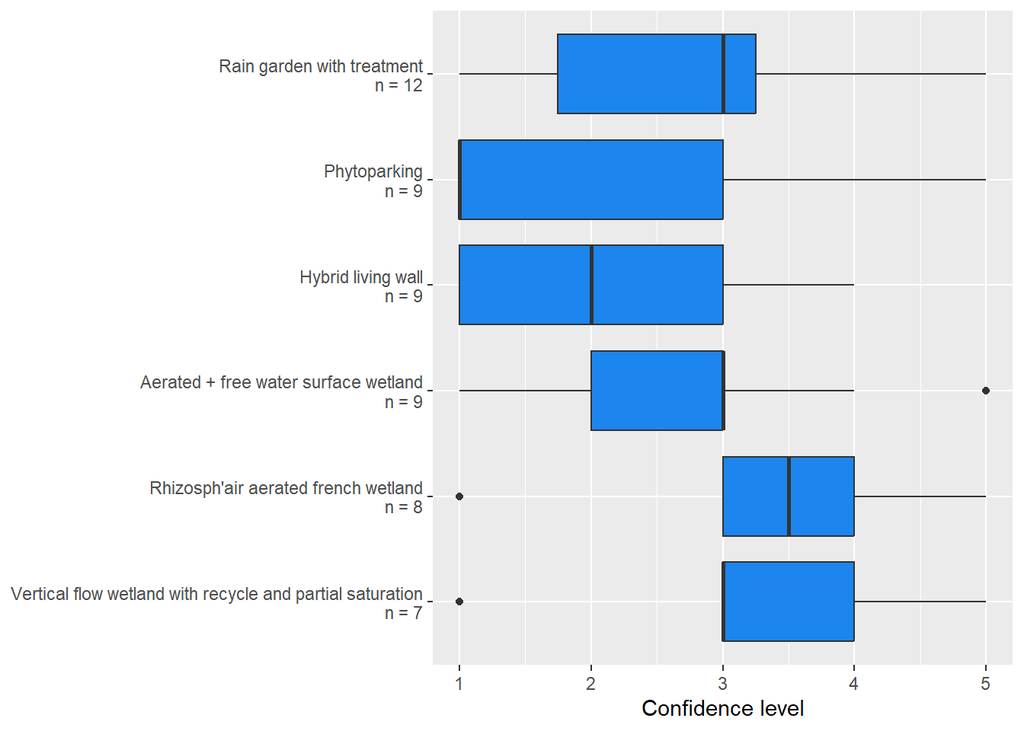

The confidence was used to weight the frequency of responses. For instance if 2 people with a confidence level of 3 responded “active”, “active” was counted 6 times (2 x 3), and if another person with a level of confidence of 5 responded “inactive”, “inactive” was counted 5 times (1 x 5). The information from the second part (groups by pilots) was given a weight of 10. All pilots have group information except the Rhizosph’air aerated french wetland (no group about this pilot was set in the annual meeting).

all the following plots of this section show the weighted frequency of responses for the different parts of the knowledge base, calculated as explained above. The $n$ shows the number of responses for that pilot in that category. For instance, there were 9 for Ammonia and Aerated + free water surface wetland. Note, that the number of responses for specific value of a technology are usually lower than the number of responses for the level of confidence. The reason is that all attendants answered the level of confidence for almost all technologies, but then left blank the specific values for some technologies, probably because theu did not know the value at all, especially when asking for the surface ratios.

### Pollutants removal

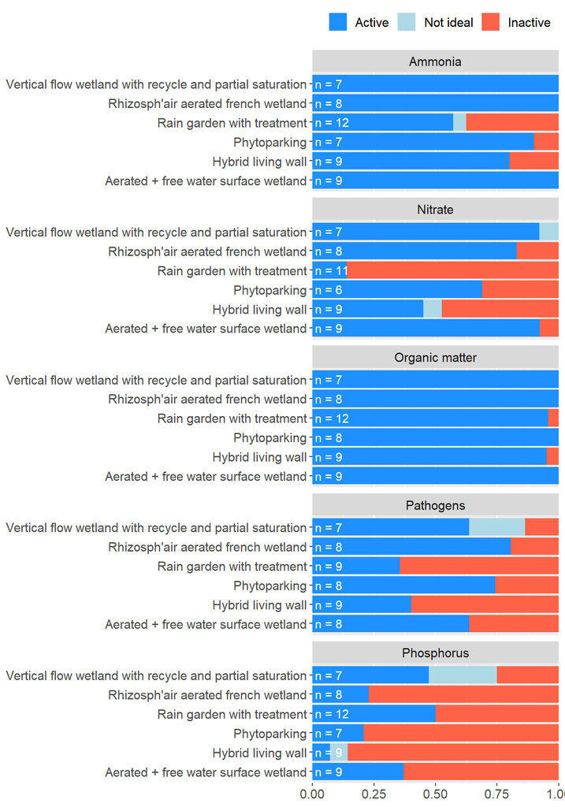

### Types of water

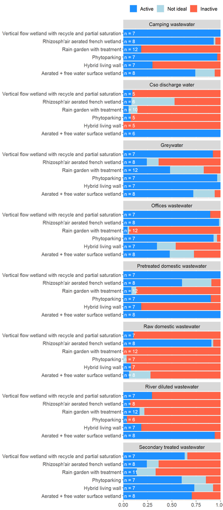

### Ratios to estimate surface

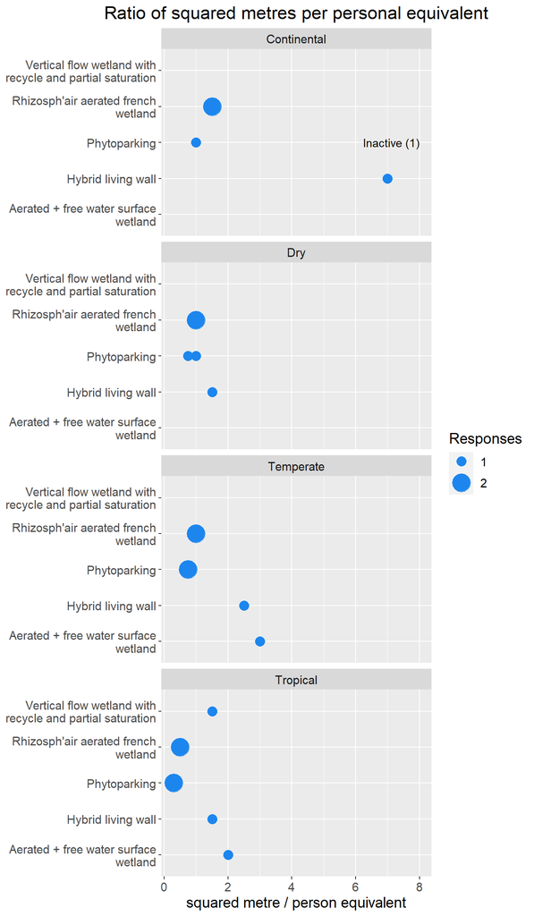

Similarly, below we show the values of gr of BOD treated by squared meter.

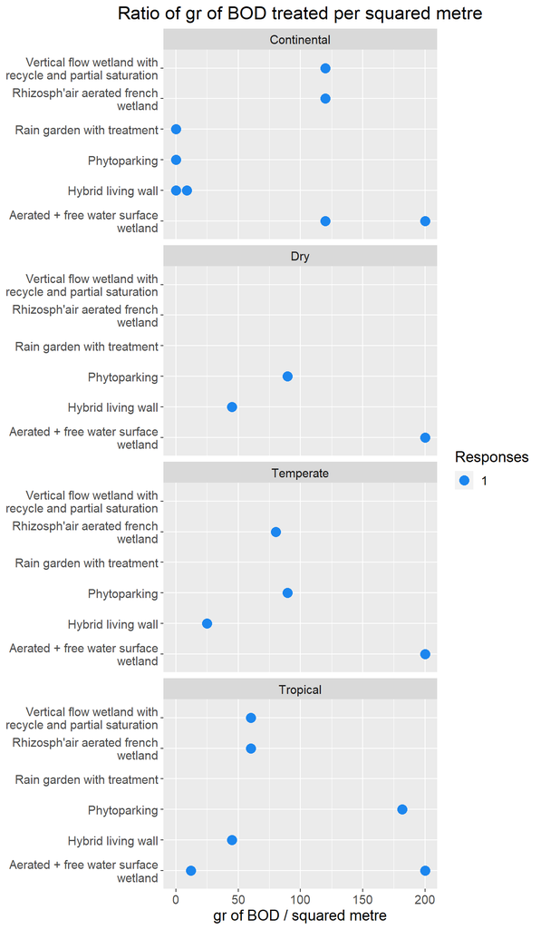

### Co-benefits

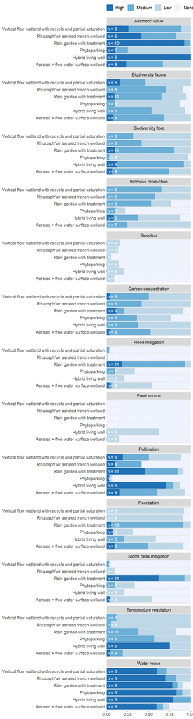

### Household building solutions

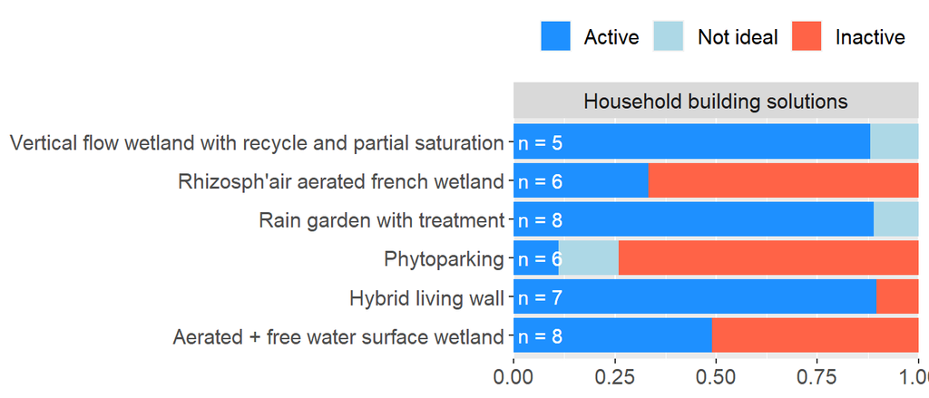

### Energy use

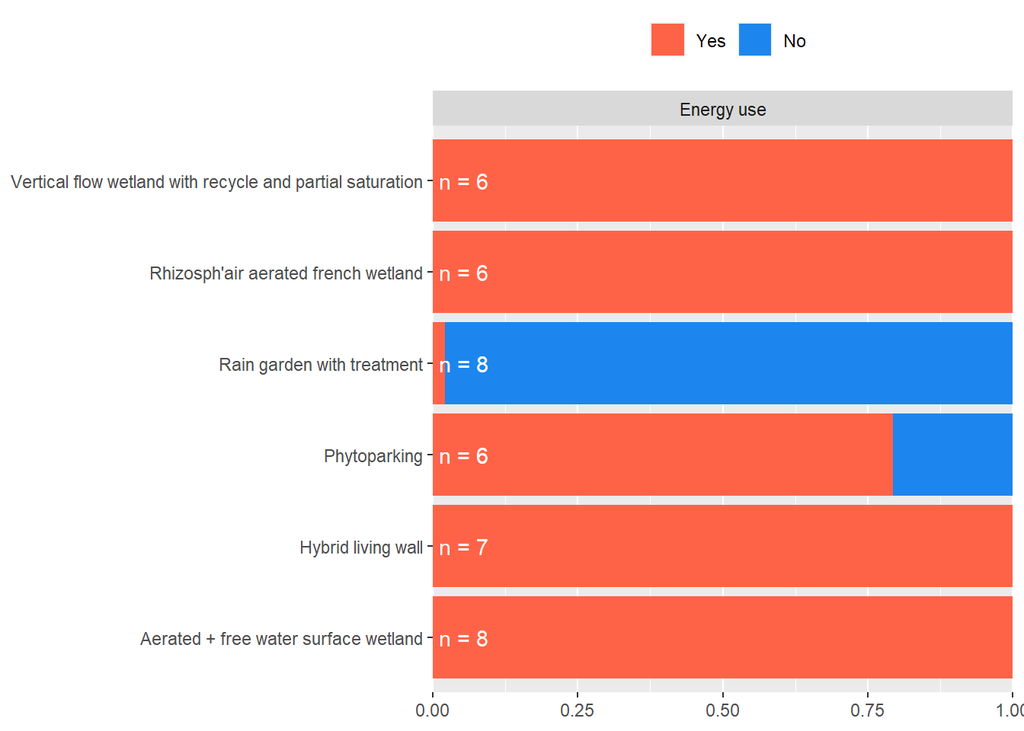

### Barriers

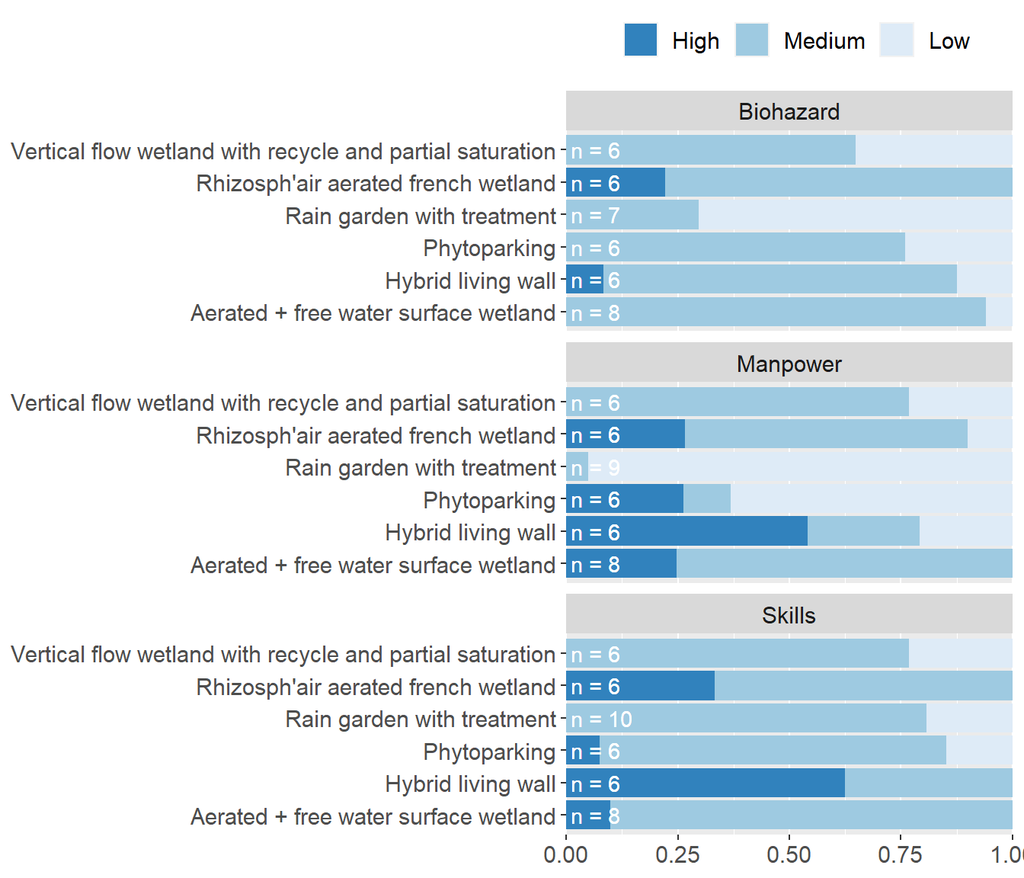

**Final outcome**

### Pollutants

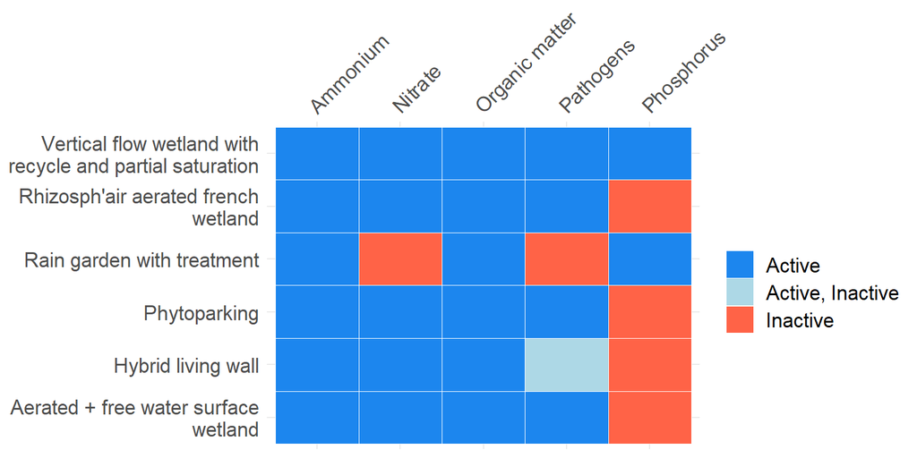

### Types of water

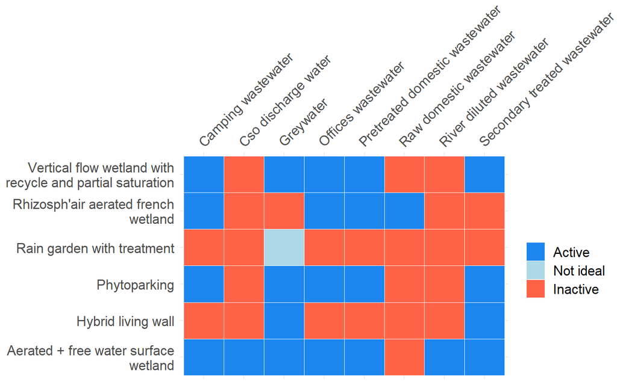

### Ratios to estimate surface

The table below show the ratio for m<sup>2</sup> per people equivalent for each climate.

| Name | Tropical | Dry | Temperate | Continental |
| --- | --- | --- | --- | --- |
| Aerated + free water surface wetland | 2.0 | Not provided | 3.00 | Not provided |
| Phytoparking | 0.3 | 0.88 | 0.75 | 1.0 |
| Rain garden with treatment | Not provided | Not provided | Not provided | Not provided |
| Rhizosph’air aerated french wetland | 0.5 | 1.00 | 1.00 | 1.5 |
| Vertical flow wetland with recycle and partial saturation | 1.5 | Not provided | Not provided | Not provided |
| Hybrid living wall | 1.5 | 1.50 | 2.50 | 7.0 |

Similarly, the next table show the ratio of gr of BOD treate per m<sup>2</sup>.

| Name | Tropical | Dry | Temperate | Continental |
| --- | --- | --- | --- | --- |
| Aerated + free water surface wetland | 157 | 200 | 200 | 182 |
| Phytoparking | 182 | 90 | 90 | 0 |
| Rain garden with treatment | Not provided | Not provided | Not provided | 0 |
| Rhizosph’air aerated french wetland | 60 | Not provided | 80 | 120 |
| Vertical flow wetland with recycle and partial saturation | 60 | Not provided | Not provided | 120 |
| Hybrid living wall | 45 | 45 | 25 | 7 |

### Co-benefits

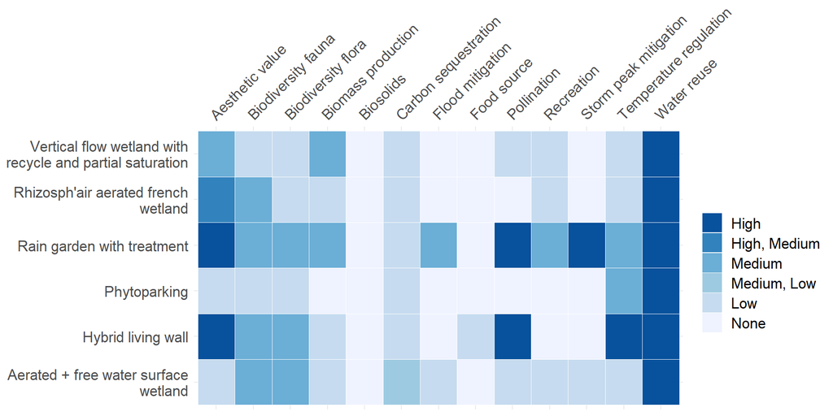

### Household building solutions and energy use

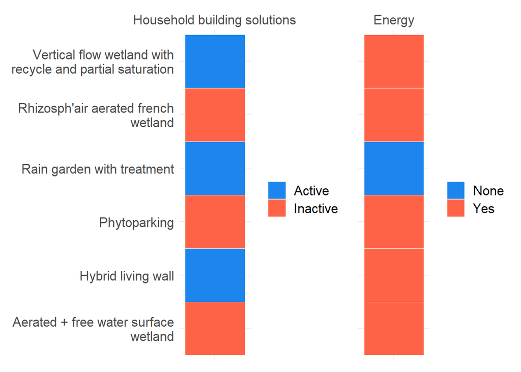

### Barriers

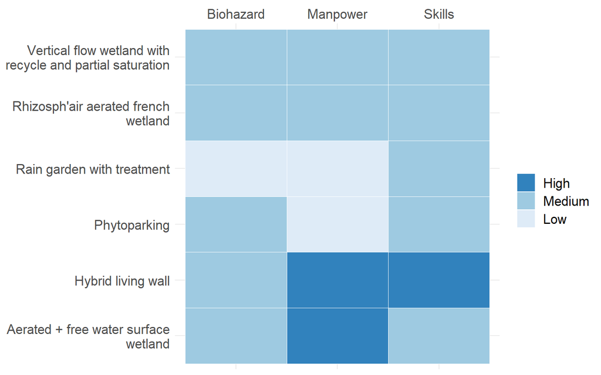